```python
from IPython.display import HTML
HTML('''
<script
    src="https://cdnjs.cloudflare.com/ajax/libs/jquery/2.0.3/jquery.min.js ">
</script>
<script>
code_show=true;
function code_toggle() {
 if (code_show){
 $('div.jp-CodeCell > div.jp-Cell-inputWrapper').hide();
 } else {
$('div.jp-CodeCell > div.jp-Cell-inputWrapper').show();
 }
 code_show = !code_show
}
$( document ).ready(code_toggle);
</script>
<form action="javascript:code_toggle()"><input type="submit"
    value="Click here to toggle on/off the raw code."></form>
''')
```

[figure not shown]

# **Abstract**

This comprehensive study Latent Semantic Analysis (LSA) to examine the dominant themes in news articles from Rappler concerning President Bongbong Marcos' first year in office. Aimed at enhancing policy-making, strategic communications, and public engagement, the research focuses on analyzing media narratives to provide insights into public discourse and political events. The study’s methodology involves collecting and processing data from Rappler, using advanced techniques like Bag-of-Words, TF-IDF, and LSA, followed by K-Means clustering to categorize themes into coherent groups. The findings reveal three primary clusters: "Political Alliances and Dynasties," "Media and Disinformation," and "International Relations and Economic Policies." These insights offer a nuanced understanding of media portrayal and public perception of political events and policies. These findings can also help in aiding in formulating strategies for policy analysis, public relations, and speech building. The study concludes by emphasizing the significance of such analytical methods in shaping effective governance and communication strategies, while recommending future research to include diverse media sources for a more balanced analysis.

# **Introduction**

## **Background**

One crucial aspect for political organizations and government administrations is their ability to track the publicities in the form of dominant themes of their actions and policies. One way to determine the administration’s performance is to assess how they are painted in the media, may it be through opinion-heavy platforms such as social media and podcasts, or more importantly, through news sites such as Inquirer and Rappler. It has been more than one year since President Bongbong Marcos’ presidency, and assessing the performance other than depending on official reports such as the State of the Nation Address (SONA) can be a valuable opportunity for their administration to look into a room for improvement for their policies and platforms.

This study therefore looks into utilizing meticulous unsupervised learning methods with the purpose of encapsulating the dominant themes of the administration on various fronts, illuminating the key areas where the government has either achieved significant milestones or faced critical issues during their past year in office. By leveraging advanced methods such as Latent Semantic Analysis, this approach aims to objectively quantify and categorize the administration's actions, providing a comprehensive overview of their performance beyond the scope of traditional reporting methods.

## **Problem Statement**

Through the use of Latent Semantic Analysis, the study aims to answer the following problem statement: **what are the dominant themes and categories of Rappler news articles that can help support in crafting and assessing presidential policies?** Specifically to support activities on:

- **Policy Analysis and Development**. To utilize Latent Semantic Analysis (LSA) to identify and categorize dominant themes in Rappler news articles. This analysis will benefit the administration in understanding the media narrative and public discourse surrounding political events and policies.
- **Strategic Communications and Public Relations**. To leverage insights from the media analysis for developing effective communication strategies for political parties, government agencies, and NGOs.
- **Speech Building and Advocacy**. To identify policy areas and social issues highlighted by the media, potentially aiding in speech construction and advocacy efforts.

## **Significance of the Study**

In conjunction with the Problem Statement, the significance of this study lies in its potential to enhance policy-making, improve strategic communications, aid in effective public engagement, and contribute to a more transparent and responsive government.

1. **Policy Analysis and Development**. This will provide a nuanced understanding of how media portrays political events and policies, aiding in the formulation and assessment of presidential policies, especially in the context of the Marcos Administration. It will also facilitate the identification of gaps between policy intent and public perception, guiding the administration in fine-tuning its approach to governance.
2. **Strategic Communications and Public Relations**. This will enhance the capacity to craft informed public messages and media relations strategies, aligning them with prevailing public sentiments and media trends. It will also provide valuable insights for managing crisis communications effectively, ensuring that responses are well-informed and timely.
3. **Speech Building and Advocacy**. This would offer a concrete measure of which policies or platforms are being prioritized, facilitating more targeted and relevant public communication and advocacy. It also provides a strategic tool for advocacy groups to align their campaigns with the most pressing and discussed issues, increasing their relevance and impact.
4. **Scalability of the Method**. This research would provide a new method for political organizations and government administrations to apply to news platforms not limited to the likes of Rappler as an assessment for their image and performance. It would also provide them the same aforementioned business values such as improving strategic communications and effective public engagement.

# **Data Sources and Description**

## **Dataset Used**

The main dataset is obtained from `rappler.com` wherein the search bar was utilized with the prompt of `marcos year 2022` as the chosen exemplar. It will contain the first 10 pages of the search results, with each page holding 10 articles, totaling 100 rows to be utilized. The dataset will have the following variables:

- `Title` – string
- `Link` – string

This dataset will be utilized by accessing the links to the articles and creating a new dataframe containing the main content or text of each article. The new dataframe will then be subjected to the process discussed in the Methodology section

## **Data Assumptions and Limitations**

- **Representativeness**. The dataset, comprising 100 articles from Rappler obtained using the search prompt `marcos year 2022`, is presumed to be representative of the overall media coverage and public discourse regarding President Marcos's administration in its first year and the years leading up to the presidency. This assumption is crucial for the generalizability of the study's findings.
- **Time-Bound Analysis**. Furthermore, the study focuses on articles from a specific time period, which may not fully capture the evolving nature of political discourse or the long-term trends in media coverage of the administration.
- **Scope of Data**. In conjunction with the assumption of Representativeness, the dataset is confined to a single news source, Rappler, which may not capture the full diversity of media narratives or public opinion. This limitation is acknowledged in the Scalability section of the Business Value, suggesting that outcomes might vary with different news sources. This indicates a need for broader analysis to understand the administration's representation more comprehensively.
- **Stability of Online Content**. The analysis is based on the assumption that the content of these articles has remained unchanged since their publication. The dataset consists of static HTML files, and any post-publication updates or edits to the articles are not considered. This assumption is important for the consistency and reliability of the data.
- **Potential Bias in Source Selection**. The exclusive use of Rappler as the data source could introduce a bias in the analysis. Different news outlets may have varying editorial slants and focuses, which can shape the portrayal of political events and figures in distinct ways.

# **Methodology**

## **Data Processing**

In the data processing phase, we applied the Bag of Words model, a method crucial for converting text into numerical features, which is essential for computational models to understand and process language. This model treats each word in the document as an individual feature, disregarding grammar and word order, but maintaining frequency, which helps in understanding the prominence of certain terms and themes.

Following this, we implemented TF-IDF (Term Frequency-Inverse Document Frequency), an approach particularly effective for text-heavy datasets. TF-IDF helps in distinguishing the importance of words in a document relative to a collection of documents, thus enhancing the Bag of Words model by reducing the weight of commonly used words and increasing the significance of unique terms. Finally, we applied Latent Semantic Analysis (LSA), a technique that aids in identifying patterns and relationships between terms and concepts in large text datasets. LSA was utilized as a key technique for determining the dominant themes within our dataset.

The singular vectors derived from LSA were subjected to K-Means clustering. This step was crucial for categorizing the identified themes into coherent groups, enhancing the clarity and specificity of our findings. To ensure the effectiveness of our clustering approach, we employed both the silhouette method and the Calinski-Harabasz index. The silhouette method provided a measure of how similar an object is to its own cluster compared to other clusters, offering insights into the appropriateness of the number of clusters. Meanwhile, the Calinski-Harabasz index helped in assessing the cluster validity by comparing the dispersion between and within clusters. These metrics were instrumental in fine-tuning our clustering approach, ensuring that the K-Means algorithm optimally grouped the themes identified by LSA.

[figure not shown]

Fig 1. High-Level Data Processing

# **Data Collection**

## **Import Relevant Libraries**

To ensure a rigorous and systematic collection of data, this study employed a suite of Python libraries known for their robustness and efficiency in data handling and analysis. These libraries include:

- `os`: For interacting with the operating system and managing file paths.
- `time`: For adding a delay during webscraping.
- `requests`: A library for webscraping.
- `numpy`: A fundamental package for numerical computations.
- `pandas`: Providing high-level data structures and analysis tools.
- `matplotlib.pyplot`: For creating static, interactive, and exploratory visualizations.
- `bs4 (BeautifulSoup)`: A library for pulling data out of HTML and XML files.
- `sklearn.cluster (KMeans)`: For performing KMeans Clustering.
- `sklearn.feature_extraction.text (TfidVectorizer)`: For Creation of Bag-Of-Words subjected to TF-IDF.
- `sklearn.decomposition (TruncatedSVD)`: For performing SVD to the Bag-of-Words.
- `yellowbrick.cluster (KElbowVisualizer)`: For Finding the optimal number of KMeans clusters.

```python
# Install yellowbrick
!pip install yellowbrick
```

```python
import os
import time
import requests
import numpy as np
import pandas as pd
import matplotlib as mpl
import matplotlib.pyplot as plt
from bs4 import BeautifulSoup
from sklearn.cluster import KMeans
from sklearn.decomposition import TruncatedSVD
from sklearn.feature_extraction.text import TfidfVectorizer
from yellowbrick.cluster import KElbowVisualizer
from IPython.display import display, display_html

mpl.rcParams.update(mpl.rcParamsDefault)
```

```python
# Ignore FutureWarnings
import warnings

warnings.simplefilter(action='ignore', category=FutureWarning)
```

## **Web Scraping Proper**

The first 10 pages of search results from Rappler were previously downloaded. Webpages in HTML format are then uploaded in a folder in Jojie as a central repository. This allows us to have a static source of generating the steps for this study and to support consistent replication in the future.

```python
# Set the file directory
data_dir = '/mnt/processed/private/msds2024/lt3'
```

```python
# Create a DataFrame from the Rappler html files
articles = []
for i in range(1, 11):
    with open(os.path.join(data_dir, f"Search with RAPPLER{i}.html")) as f:
        soup = BeautifulSoup(f).find_all(
            "div", class_="gs-bidi-start-align gs-snippet", dir="ltr"
        )
    for item in soup:
        articles.append(
            {
                "Title": item.find_previous("a").text.strip(),
                "Link": item.find_previous("a")["href"],
            }
        )
df = pd.DataFrame(articles)
```

# **Data Exploration**

This section shows the checks and validations performed to ensure completeness and acurracy of processed data.

```python
print(f'Shape of the DataFrame: {df.shape}')
```

```
Shape of the DataFrame: (100, 2)
```

```python
print('Check for Blank Cells:')
df.isnull().sum()
```

```
Check for Blank Cells:
```

```
Title    0
Link     0
dtype: int64
```

```python
display(df.head())
display(
    HTML(
        "<i style='margin-left: 200px;'>Table 1. First 5 Rows of Titles"
        " and Links</i>"
    )
)
```

|  | Title | Link |
| --- | --- | --- |
| 0 | 36 years after ousting Marcos, Filipinos elect... | https://www.rappler.com/nation/elections/ferdi... |
| 1 | Tracking the Marcos disinformation and propaga... | https://www.rappler.com/newsbreak/iq/stories-t... |
| 2 | FULL TEXT: President Marcos' State of the Nati... | https://www.rappler.com/nation/full-text-trans... |
| 3 | FALSE: Nostradamus predicts Bongbong Marcos wi... | https://www.rappler.com/newsbreak/fact-check/n... |
| 4 | Hundreds killed in drug war during Marcos' 1st... | https://www.rappler.com/nation/death-toll-drug... |

*Table 1. First 5 Rows of Titles and Links*

# **Data Processing**

This section demonstrates the representation of documents into Bag-of-Words, information retrieval, and performance evaluation.

## **Bag-of-Words Representation**

```python
# Create the corpus from the Rappler links
corpus = []
for link in df["Link"]:
    corpus.append(
        BeautifulSoup(requests.get(link).text)
        .find("div", class_="post-single__content entry-content")
        .text
    )
    time.sleep(0.2)
```

```python
print('Length of Corpus: ', len(corpus))
```

```
Length of Corpus:  100
```

## **TF-IDF**

The bag-of-words were subjected to TF-IDF with the same token pattern `\b[a-z]{3,}\b` and `stop_words="english"`

```python
# Apply the TfidfVectorizer to create a bag-of-words with TF-IDF
tfidf = TfidfVectorizer(
    min_df=5, max_df=0.8, token_pattern=r"\b[a-z]{3,}\b", stop_words="english"
)
bow = tfidf.fit_transform(corpus)
df_bow = pd.DataFrame(bow.toarray(), columns=tfidf.get_feature_names_out())
```

```python
display(df_bow)
display(HTML('<center><i>Table 2. Preview of Bag-of-Words</i></center>'))
```

|  | ability | able | abroad | abs | abuses | academic | access | accessible | accompanied | according | ... | years | yellow | york | young | younger | youngest | youth | youtube | yun | yung |
| --- | --- | --- | --- | --- | --- | --- | --- | --- | --- | --- | --- | --- | --- | --- | --- | --- | --- | --- | --- | --- | --- |
| 0 | 0.000000 | 0.063587 | 0.000000 | 0.0 | 0.000000 | 0.000000 | 0.000000 | 0.050729 | 0.0 | 0.000000 | ... | 0.019116 | 0.0 | 0.0 | 0.000000 | 0.0 | 0.000000 | 0.0 | 0.000000 | 0.000000 | 0.0 |
| 1 | 0.000000 | 0.000000 | 0.000000 | 0.0 | 0.000000 | 0.000000 | 0.000000 | 0.000000 | 0.0 | 0.000000 | ... | 0.057389 | 0.0 | 0.0 | 0.000000 | 0.0 | 0.000000 | 0.0 | 0.169842 | 0.000000 | 0.0 |
| 2 | 0.006966 | 0.028326 | 0.006009 | 0.0 | 0.000000 | 0.007533 | 0.011201 | 0.007533 | 0.0 | 0.000000 | ... | 0.005677 | 0.0 | 0.0 | 0.011201 | 0.0 | 0.000000 | 0.0 | 0.000000 | 0.000000 | 0.0 |
| 3 | 0.000000 | 0.000000 | 0.000000 | 0.0 | 0.000000 | 0.000000 | 0.000000 | 0.000000 | 0.0 | 0.060173 | ... | 0.026960 | 0.0 | 0.0 | 0.053192 | 0.0 | 0.000000 | 0.0 | 0.000000 | 0.000000 | 0.0 |
| 4 | 0.000000 | 0.000000 | 0.000000 | 0.0 | 0.033047 | 0.043463 | 0.000000 | 0.000000 | 0.0 | 0.018277 | ... | 0.032756 | 0.0 | 0.0 | 0.000000 | 0.0 | 0.000000 | 0.0 | 0.000000 | 0.000000 | 0.0 |
| ... | ... | ... | ... | ... | ... | ... | ... | ... | ... | ... | ... | ... | ... | ... | ... | ... | ... | ... | ... | ... | ... |
| 95 | 0.000000 | 0.000000 | 0.000000 | 0.0 | 0.000000 | 0.000000 | 0.000000 | 0.000000 | 0.0 | 0.137222 | ... | 0.000000 | 0.0 | 0.0 | 0.000000 | 0.0 | 0.000000 | 0.0 | 0.000000 | 0.000000 | 0.0 |
| 96 | 0.000000 | 0.000000 | 0.000000 | 0.0 | 0.000000 | 0.000000 | 0.000000 | 0.000000 | 0.0 | 0.016857 | ... | 0.000000 | 0.0 | 0.0 | 0.000000 | 0.0 | 0.000000 | 0.0 | 0.000000 | 0.000000 | 0.0 |
| 97 | 0.000000 | 0.000000 | 0.000000 | 0.0 | 0.000000 | 0.000000 | 0.000000 | 0.000000 | 0.0 | 0.000000 | ... | 0.020407 | 0.0 | 0.0 | 0.000000 | 0.0 | 0.000000 | 0.0 | 0.000000 | 0.048411 | 0.0 |
| 98 | 0.000000 | 0.000000 | 0.000000 | 0.0 | 0.000000 | 0.000000 | 0.000000 | 0.000000 | 0.0 | 0.039346 | ... | 0.052887 | 0.0 | 0.0 | 0.000000 | 0.0 | 0.000000 | 0.0 | 0.000000 | 0.000000 | 0.0 |
| 99 | 0.000000 | 0.000000 | 0.000000 | 0.0 | 0.000000 | 0.000000 | 0.000000 | 0.000000 | 0.0 | 0.027949 | ... | 0.012523 | 0.0 | 0.0 | 0.000000 | 0.0 | 0.031892 | 0.0 | 0.000000 | 0.000000 | 0.0 |

100 rows × 1919 columns

*Table 2. Preview of Bag-of-Words*

## **Determining the Number of Singular Vectors**

Using the plot of `Variance Explained` vs `SV`, we determine how much Singular Vectors we have to retain, analyze, and cluster, with the cumulative variance of 0.9.

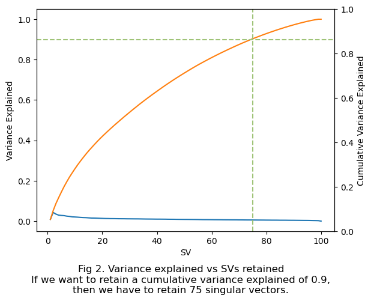

```python
# Plot the cumulative variance explained and find the number of SVs to retain
pct = 0.9
svd = TruncatedSVD(n_components=max(bow.shape))
svd.fit(bow)
var = svd.explained_variance_ratio_
n = np.where(var.cumsum() > pct)[0][0] + 1
fig, ax = plt.subplots()
ax.plot(range(1, len(var)+1), var, '-', label='individual')
ax.plot(range(1, len(var) + 1), var.cumsum(), label='cumulative')
ax.axhline(pct, ls="--", color="g")
ax.axvline(n, ls="--", color="g")
plt.xlabel("SV")
plt.ylabel('Variance Explained')
ax = ax.twinx()
ax.set_ylabel("Cumulative Variance Explained")
fig.text(
    0.5,
    -0.1,
    f"Fig 2. Variance explained vs SVs retained\n"
    f"If we want to retain a cumulative variance explained of {pct},\n"
    f"then we have to retain {n} singular vectors.",
    wrap=True,
    horizontalalignment="center",
    fontsize=12,
)
plt.show()
```

## **Truncated SVD and Exploring First Five SVs**

In order to highlight the most significant singular values in the data, we subjected the bag-of-words to TruncatedSVD, and we analyze the first five SVs:

- *SV1: Unity Tandem.*
- *SV2: Foreign Policy*
- *SV3: Fake News*
- *SV4: Commodity Prices*
- *SV5: COMELEC Case*

and so on...

```python
# Apply TruncatedSVD to the bag-of-words
svd = TruncatedSVD(n_components=n)
bow_svd = svd.fit_transform(df_bow)
V_T = svd.components_.T
```

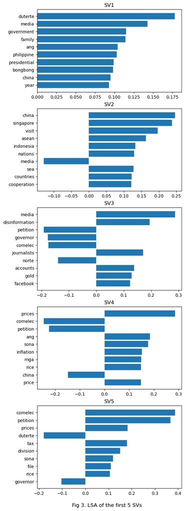

```python
feature_names = tfidf.get_feature_names_out()
fig, axs = plt.subplots(5, 1, figsize=(6, 20))
for i in range(5):
    # fig, ax = plt.subplots()
    order = np.argsort(np.abs(V_T[:, i]))[-10:]
    axs[i].barh([feature_names[o] for o in order], V_T[order, i])
    axs[i].set_title(f"SV{i+1}")
fig.text(
    0.5,
    0.08,
    "Fig 3. LSA of the first 5 SVs",
    wrap=True,
    horizontalalignment="center",
    fontsize=12,
)
plt.show()
```

## **K-Means Clustering with Silhouette Score and Calinksi Harabasz**

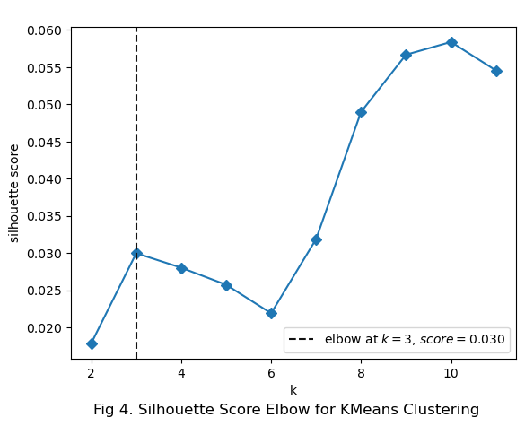

```python
# Instantiate the clustering model and elbow visualizer
model = KMeans(n_init="auto", random_state=0)
visualizer = KElbowVisualizer(
    model, k=(2, 12), metric="silhouette", timings=False, title=" "
)

# Fit the data to the visualizer and render the figure
fig, ax = plt.subplots()
visualizer.fit(bow_svd)
fig.text(
    0.5,
    -0.02,
    "Fig 4. Silhouette Score Elbow for KMeans Clustering",
    wrap=True,
    horizontalalignment="center",
    fontsize=12,
)
visualizer.show(ax=ax);
```

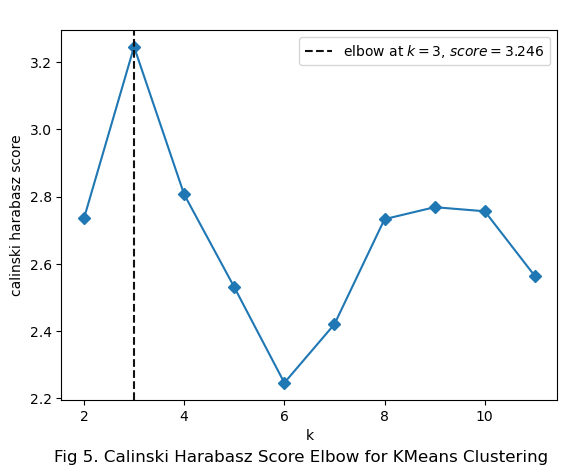

```python
# Instantiate the clustering model and elbow visualizer
model = KMeans(n_init="auto", random_state=0)
visualizer = KElbowVisualizer(
    model, k=(2, 12), metric="calinski_harabasz", timings=False, title=" "
)

# Fit the data to the visualizer and render the figure
fig, ax = plt.subplots()
visualizer.fit(bow_svd)
fig.text(
    0.5,
    -0.02,
    "Fig 5. Calinski Harabasz Score Elbow for KMeans Clustering",
    wrap=True,
    horizontalalignment="center",
    fontsize=12,
)
visualizer.show(ax=ax);
```

## **Plotting the K-Means Cluster**

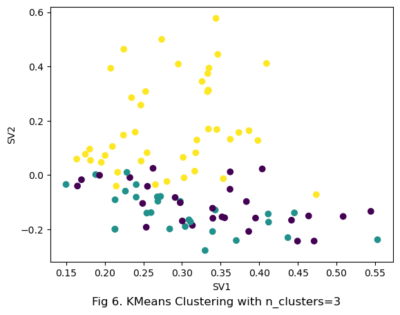

```python
# Fit the bag-of-words with KMeans
kmeans = KMeans(
    n_clusters=visualizer.elbow_value_, n_init="auto", random_state=0
)
kmeans.fit(bow_svd)

# Plot the KMeans clusters
fig, ax = plt.subplots()
ax.scatter(bow_svd[:, 0], bow_svd[:, 1], c=kmeans.labels_)
plt.xlabel("SV1")
plt.ylabel("SV2")
fig.text(
    0.5,
    -0.02,
    f"Fig 6. KMeans Clustering with n_clusters={visualizer.elbow_value_}",
    wrap=True,
    horizontalalignment="center",
    fontsize=12,
)
plt.show()
```

```python
# Find the most influential words per cluster
original_space_centroids = svd.inverse_transform(kmeans.cluster_centers_)
order_centroids = original_space_centroids.argsort()[:, ::-1]
terms = tfidf.get_feature_names_out()

print("Most Influential Words per Cluster")

for i in range(kmeans.cluster_centers_.shape[0]):
    print(f"\033[3{i+1}mCluster {i}: ", end="")
    for ind in order_centroids[i, :10]:
        print(f"{terms[ind]} ", end="")
    print()
```

```
Most Influential Words per Cluster
Cluster 0: duterte governor norte bongbong party sara vice presidential ilocos family
Cluster 1: media disinformation accounts comelec journalists gold duterte petition twitter family
Cluster 2: china singapore visit sona government state economic year prices philippine
```

```python
# Print the article titles by cluster
print("Article Titles by Cluster")
df_cluster = pd.DataFrame([df["Title"], kmeans.labels_]).T.rename(
    columns={"Unnamed 0": "Label"}
)

for label in df_cluster.Label.unique():
    for title in df_cluster.set_index("Label")["Title"][label]:
        print(f"\033[3{label+1}m{title}")
```

```
Article Titles by Cluster
36 years after ousting Marcos, Filipinos elect son as president
Marcos-Duterte 'Uniteam' seals 2022 alliance
RECORDS: Bongbong Marcos' 1997 tax conviction hounds him in ...
At least 6 Marcos donors in 2022 campaign given gov't posts
Bongbong Marcos-Sara Duterte tandem now official
LIST: Local officials killed under Marcos gov't
Marcos Jr. in Ilocos Norte: Absentee governor who 'could have done ...
36 years after exile, Ferdinand Marcos Jr. takes oath as Philippine ...
Tycoons booze up at Marcos' victory party
Dictator's son Bongbong Marcos to run for president in 2022
Dictator's son Bongbong Marcos files candidacy for president
KBL nominates Bongbong Marcos for president
As Philippine president, Marcos could control hunt for his family's ...
Liza Araneta Marcos, First Lady of the Philippines
Marcos and Duterte talk 2023 resolutions, 'predictions' in New Year ...
Political Dynasties 2022: Fariñas clan foil to Marcos power in Ilocos ...
What's Bongbong Marcos' 2022 plan? 'Everyone's rethinking'
[QUIZ] Guess who? Names that dominated the headlines during ...
Marcoleta top pick in 10-member Marcos-Duterte Senate slate
Surigao del Norte cult forced members to vote Marcos-Sara in 2022 ...
Marcos names Romeo Lumagui Jr. as BIR chief
Telcos deny Bongbong Marcos text ad; NTC points to portable cell ...
Sandro Marcos, 15 governors join President's Partido Federal ng ...
A 2022 thank you? First Lady says Marcos keen on proposed LGBT ...
Cebu turns red: Former opposition bailiwick gives Marcos his ...
In 2-0 vote, Comelec body allows Marcos Jr. to run for president
PDP-Laban bigwigs form new party as Marcos enters second year
'Napag-initan:' Bongbong Marcos campaigns for plunder defendant ...
Tracking the Marcos disinformation and propaganda machinery
FALSE: Nostradamus predicts Bongbong Marcos will lead ...
Marcos and the media: Platitudes, but what else again?
Marcos Jr. is top pick of Generation Z, says Pulse Asia survey
Pro-Marcos, Duterte accounts step up attacks on journalists as 2022 ...
LIST: Petitions seeking to block Bongbong Marcos' 2022 ...
Marcos Jr. benefited from Facebook – study
LIST: Petitions seeking to block Bongbong Marcos' 2022 ...
Duterte 'institutionalized' disinformation, paved the way for a Marcos ...
Here is unity: The different faces of the Marcos 30 million
Marcos Jr.'s campaign reaping benefits of years of disinformation ...
```

[output cut: 46 more lines]

```
Marcos and Duterte want to be neutral on Ukraine invasion
Mindanao groups disappointed as Marcos' SONA ignores their ...
BREAKDOWN: P174B recovered from Marcos loot, P125B more to get
Marcos meets Blinken, says PH-US ties crucial amid Taiwan tension
[WATCH] #StoryOfTheNation: What do Filipinos say about the first ...
FACT CHECK: Food prices remain high under Marcos
[ANALYSIS] Marcos at Davos: Economic lies and cherry-picking galore
The billionaires advising Marcos how to run the economy
[ANALYSIS] After a year under Marcos, is PH economy grinding to a ...
[OPINION] Flexible foreign policy: Balancing PH relations with US ...
DOF urges Marcos: Postpone income tax cuts, slap new taxes, slash ...
HIGHLIGHTS: President Ferdinand Marcos Jr.'s first State of the ...
Marcos to host banquet for Malaysia's Anwar during official visit
42% of Filipinos disapprove of Marcos gov't response to inflation ...
What you need to know about Marcos' first ASEAN summit
```

# **Analysis and Results**

After performing K-means clustering, we arrived at three dominant clusters.

We can call these clusters as follows:

- `Cluster 0`: **"Political Alliances and Dynasties"**

  This cluster seems to focus on political figures, regional governance, and connections in politics. The keywords like `duterte`, `bongbong`, `presidential`, `vice`, and `party` suggest a focus on political personalities and their influence in regional and national politics. While the exemplar of our database explicitly mentioned `marcos`, we can see a strong correlation with this word to other political personalities and affiliations. Ferdinand ‘Bongbong’ Marcos Jr. is paired with Sara Duterte and their alliance in the 2022 election has shown to be a formidable force after getting more than 50% of the popular votes for both presidential and vice presidential posts.
- `Cluster 1`: **"Media and Disinformation"**

  This cluster includes keywords such as `media`, `journalists`, and `twitter`, pointing to the role of media and social media in the political landscape. Meanwhile, keywords like `disinformation`, and `gold`, highlight a critical threat to the integrity of media, and journalism.
- `Cluster 2`: **"International Relations and Economic Policies"**

  Keywords like `china`, `singapore`, `sona` (State of the Nation Address), `economic`, and `government` suggest a focus on international relations, economic policies, and government strategies. This cluster likely covers the country's diplomatic engagements and economic initiatives, as well as their impact on local economic factors like prices.

## **Actionable Insights**

In the political arena, the year 2022 is a turning point in the transition of presidential powers from one administration to another. Therefore, it is expected that election-related news will have its own cluster in the list of articles in our corpus given the exemplar `marcos year 2022`. This boils down to one of the clusters related to political alliances and dynasties. However, the second cluster has ties again with elections tackling the connection of media and disinformation with the exemplar.

With `k=3` as the optimal number of clusters, two of the clusters are not directly associated with policies and programs. Thus, the stakeholder may only refer to the third cluster in terms of policy analysis and development. The researchers selected a few of the keywords from this cluster as a baseline for the insights on policy making.

**Policy Analysis and Development**. These keywords may reflect pressing issues and concerns that the office of the president can prioritize.

- `china` **China’s Claim on the West Philippine Sea.** The Philippines faces a significant challenge to its sovereignty due to China's expansive territorial claims in the West Philippine Sea. Results from dimensionality reduction indicate that this issue should be a top priority for the presidential administration. It is imperative that a comprehensive set of policies and strategies be developed to assert and secure the nation’s territorial rights.
- `price` **Increasing Prices of Basic Commodities.** The rising inflation has led to a substantial increase in the prices of basic commodities that have made headlines. A notable example of this is the price of onions, which has skyrocketed to P700 per kilogram surpassing the cost of meat. This has contributed to a significant financial burden on consumers. This kind of phenomenon must be considered in influencing policies pertaining to agriculture and trade.
- `singapore` **International Relations and Travel.** The president also made regular international trips for state visits in various locations globally with the intention of acquiring investments and grants from abroad. The result of the dimensionality reduction of news articles can be used in assessing how these travels are perceived by the media. One controversial event is the president’s travel to Singapore to attend the 2022 Grand Prix. As published in the news, critics have lambasted this move saying that this is an unnecessary expense. However, the office of the president refuted that this is to network with prospective investors for our country.

**Public Relations and Image**. Aside from shaping presidential policies, the results from the dimensionality reduction can be used to assess how the president is perceived by the media.

- **Proliferation of Fake News and Disinformation.** From cluster 1, the President’s image could be tainted with controversy on disinformation and fake news. They may investigate these allegations and properly clarify them through their communications team if needed.
- **Absence of Ideal Keywords.** To address the absence of ideal keywords that would elevate the president’s visibility in public works, a strategic communications plan should be developed. This plan should highlight the president's active role in the execution and inauguration of key public works and infrastructure projects.

**Pointers for Speech Building**. By analyzing the reduced dimensions, presidential speechwriters can identify the most notable themes and topics that resonate with the public. This can be a pointer in preparation for the State of the Nation Address (SONA) where both the media and the citizens might want to hear updates on relevant and pressing issues. For example, if the dimensionality reduction reveals an emphasis on calamity resiliency, the SONA can highlight the administration’s contribution to this area. If there's a significant discourse on the hike in wages, the speech can outline future initiatives to meet this clamor.

[figure not shown]

Fig 7. Actionable Insights

# **Conclusion**

Using Latent Semantic Analysis (LSA) to analyze Rappler news articles, this study has identified key themes and narratives that surround President Bongbong Marcos' first year in office. The three identified clusters - "Political Alliances and Dynasties," "Media and Disinformation," and "International Relations and Economic Policies" - provide a multifaceted view of the current political and economic climate that the Marcos administration is facing. The utilization of LSA and clustering as a tool has been pivotal in this study to objectively discern these dominant themes, which demonstrated its efficacy in extracting meaningful insights from complex media narratives.

The insights mentioned provide an assessment of how the administration's image and actions are being perceived and reported. This information is particularly valuable for the Presidential Communications Office and other stakeholders in crafting strategies for policy analysis and development, public relations, and speech building. The findings suggest potential areas where the administration may need to focus its efforts, such as addressing issues related to combating disinformation and managing international relations and economic policies effectively.

In conclusion, the study not only sheds light on the current state of political and economic affairs under the Marcos administration but also highlights the importance of advanced analytical methods like LSA in shaping effective governance and communication strategies.

# **Recommendation**

It is important to acknowledge the limitations of this study, primarily the reliance on a single news source. This may introduce certain biases in the portrayal of the administration. Future research could expand the scope to include a broader range of media organizations to make our database more balanced. In addition, continuous monitoring and analysis using LSA could help in tracking the evolving nature of media narratives, thereby enabling more dynamic and responsive policy-making and communication strategies.

# **Acknowledgement**

This study was made possible through the collected data via web scraping from the website Rappler, which includes headlines and snippets of the articles.

We would also like to acknowledge Prof. Christian Alis for his mentorship and tools introduced to us that enabled us to achieve this research.

# **References**

1. Aggarwal, C. (2015). *Data Mining: The Textbook.*
2. Alis, C. (2023). SVD and SLA. Unpublished Jupyter Notebook, Data Mining and Wrangling 1 (DMW1) Course, Master of Science in Data Science, Asian Institue of Management, Makati City, Philippines.
3. Rappler. https://www.rappler.com/